# Proposition d’analyse des données de gliome malin pédiatrique

Vincent Guillemot & Cathy Philippe

2023-06-08

## Préambule

On commence par charger la librarie `RGCCA` et les données.

```r
library(RGCCA)
load("ge_cgh_locIGR.rda")
```

Puis on prépare les données pour les mettre dans des objets compatibles avec l’utilisation de RGCCA.

```r
y <- factor(colnames(ge_cgh_locIGR$multiblocks$y)[ge_cgh_locIGR$ylabel])
A <- list(
  GE = ge_cgh_locIGR$multiblocks$GE,
  CGH = ge_cgh_locIGR$multiblocks$CGH,
  y = y)
```

## Validation croisée

On effectue une validation croisée de type $k$-fold (avec $k = 5$). Pour plus d’information sur la validation croisées, voir la page (succincte) sur [Wikipedia](https://fr.wikipedia.org/wiki/Validation_crois%C3%A9e).

```r
C <- matrix(c(0, 0, 1,
              0, 0, 1,
              1, 1, 0),
            3, 3)

set.seed(5679)
res.sgcca.cv <- rgcca_cv(
  blocks = A,
  response = 3,
  method = "sgcca",
  scheme = "factorial",
  tau = c(1, 1, 0),
  connection = C,
  ncomp = c(1, 1, 1),
  par_type = "sparsity",
  par_value = as.matrix(expand.grid(
    (3:10)/sqrt(15702),
    (3:10)/sqrt(1229),
    1)),
  validation = "kfold",
  prediction_model = "lda",
  metric="Accuracy",
  n_run = 10,
  n_cores = 4)
```

Les résultats de la validation croisée sont présentés ci-après.

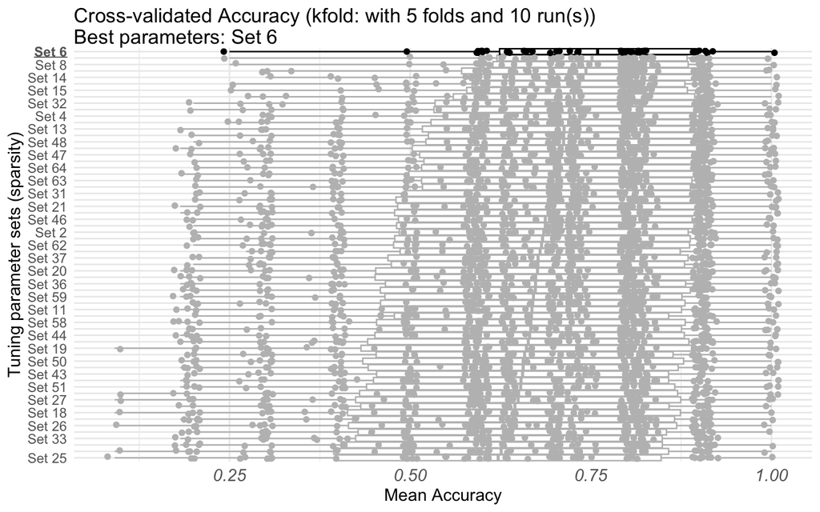

```r
plot(res.sgcca.cv)
```

Une fois la validation croisée terminée, la fonction `rgcca` est capable, à partir des résultats, d’appliquer la méthode SGCCA avec les valeurs optimales des paramètres de parcimonie.

```r
res.sgcca.opt <- rgcca(res.sgcca.cv)
```

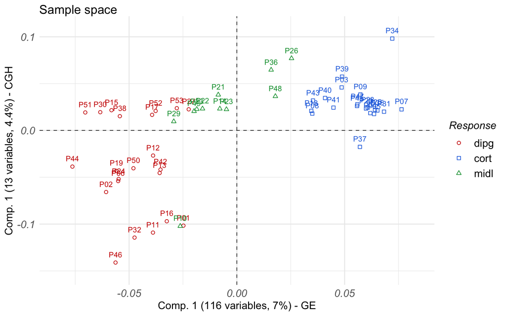

```r
plot(res.sgcca.opt, type = "samples")
```

Le nombre de variable sélectionné est de 116 pour l’expression de gènes et de 13 pour les segments CGH.

Dans cette version du jeu de données, nous n’avons pas beaucoup plus d’information sur les gènes et sur les segments, donc on ne peut pas vraiment aller plus loins. Mais après avoir obtenu ces résultats, il serait tout à fait possible de faire des analyses complémentaires (enrichissement par exemple)